# Assignment 2

# Question:

- Task 1: Read data using a relative path

```r
library(tidyverse)
college_data <- read_csv("../collegedata.csv")
```

- Task 2:Determine rows and columns

```r
college_data %>%
  summarise(rows = n())
```

```
# A tibble: 1 × 1
   rows
  <int>
1  7175
```

```r
college_data %>%
  summarise(columns = ncol(pick(everything())))
```

```
# A tibble: 1 × 1
  columns
    <int>
1      12
```

I used summarise() and n() to determine the number of rows in the dataset. I also used pick(everything()) with ncol() to determine the number of columns. The dataset contains 7,175 rows and 12 columns.

- Task 3: Use tidyverse to select INSTNM, SAT_AVG, and ADM_RATE

```r
college_selected <- college_data %>%
  select(INSTNM, SAT_AVG, ADM_RATE)

college_selected
```

```
# A tibble: 7,175 × 3
   INSTNM                              SAT_AVG ADM_RATE
   <chr>                                 <dbl>    <dbl>
 1 Alabama A & M University                849    0.874
 2 University of Alabama at Birmingham    1125    0.581
 3 Amridge University                       NA   NA
 4 University of Alabama in Huntsville    1257    0.763
 5 Alabama State University                825    0.459
 6 The University of Alabama              1202    0.526
 7 Central Alabama Community College        NA   NA
 8 Athens State University                  NA   NA
 9 Auburn University at Montgomery        1009    0.766
10 Auburn University                      1217    0.805
# ℹ 7,165 more rows
```

I used the select() function from the tidyverse to keep only the INSTNM, SAT_AVG, and ADM_RATE variables from the dataset. The resulting dataset contains only these three columns.

- Task 4: Create a scatterplot for SAT_AVG and ADM_RATE (Remove NA)

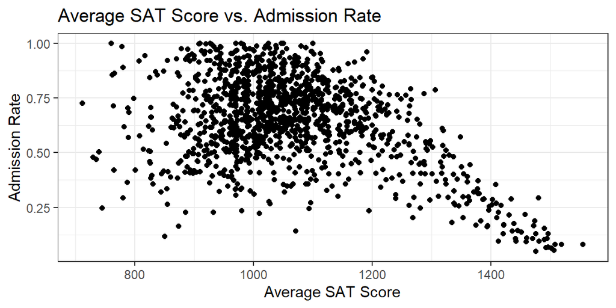

```r
college_selected %>%
  drop_na(SAT_AVG, ADM_RATE) %>%
  ggplot(aes(x = SAT_AVG, y = ADM_RATE)) +
  geom_point() +
  labs(
    x = "Average SAT Score",
    y = "Admission Rate",
    title = "Average SAT Score vs. Admission Rate"
  )
```

I first removed rows with missing values for SAT_AVG or ADM_RATE using drop_na(). I then used ggplot() and geom_point to create a scatterplot, with average SAT score on the x-axis and admission rate on the y-axis. The plot allows us to see the relationship between these two variables.